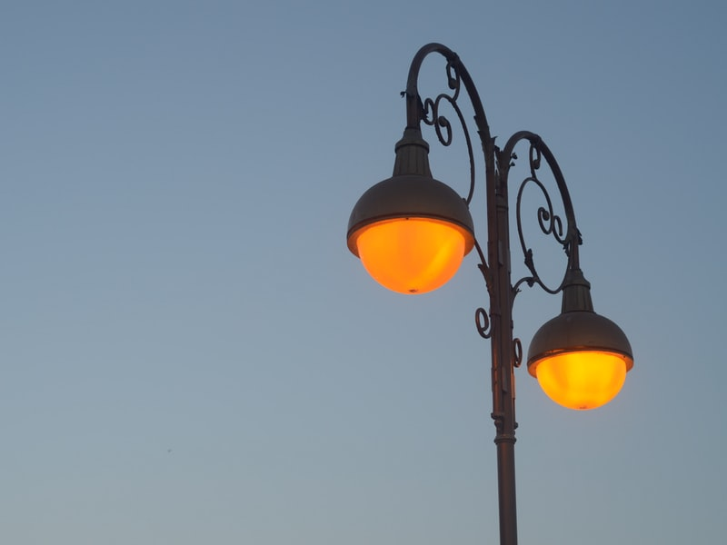

## Why this project?

Identifying the key functions of human genes is a major biomedical research goal. While some genes are very well-studied, most human genes we know little about. Mapping a broad set of gene functions *en masse* is currently not possible, and therefore most scientific research proceeds with a one-gene-at-a-time approach. While this reductionist approach has guided the scientific methods for hundreds of years, the volume, complexity, and sophistication of modern science necessitate alternative approaches.

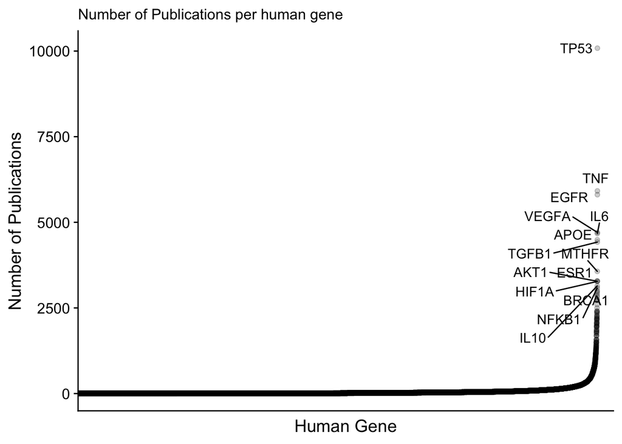

New tools in Data Science – a combination of computer programming, math & statistics, and topical expertise – combined with the rapid adoption of open science and data sharing allow scientists to access publicly available datasets and interrogate these data *before* performing any experiments.

Such tools allow researchers to identify new hypotheses for well-studied genes, or new processes for un-annotated genes. Indeed, most human genes are poorly studied, perhaps because of the intractability to study them with no prior knowledge.

This project aims to address this challenge. Welcome to data-driven hypothesis.

## What is this project?

The overall goal of the data-driven hypothesis (DDH) project is to use new tools in Data Science to generate hypotheses supported by data that can be tested in the lab. Several high-quality, functional genomic datasets are published online and made available with Creative Commons Attribution 4.0 International [(CC BY 4.0)](https://creativecommons.org/licenses/by/4.0/) licenses. Functional genomics is a field of molecular biology that aims to understand the function of all genes and proteins in a genome – a stated goal of much basic science research. In functional genomics, experimental strategies generally involve high-throughput, genome-wide approaches rather than a more traditional “gene-by-gene” approach. The advent and rapid adoption of data-sharing platforms, such as figshare.com have provided high-quality data sets for public interrogation.

We present here a comprehensive resource for functionally mapping thousands of genes across the human genome. Importantly, this method integrates gene essentiality, gene expression, and literature mining to identify candidate functions of known or unknown genes. The DDH project holds tremendous promise to generate hypotheses, data, and knowledge in order to provide a deep understanding of the dynamic properties of an organism. We provide this resource via an intuitive online interface, which will provide the scientific community a platform to query and prioritize experimental hypotheses to test in the lab.

## How does it work?

This project began as an extension of a simple and common concept in molecular biology called gene co-expression analysis. When a gene of unknown function is identified, one strategy to learn something about the new gene is to identify shared patterns of expression with other genes. If unknown Gene X is expressed with known genes A, B, and C, then you can infer that Gene X might be part of a functional module with A, B, C. This approach is particularly powerful when genes A, B, and C are part of a known biological pathway, which leads to the hypothesis that Gene X might also be part of that same pathway.

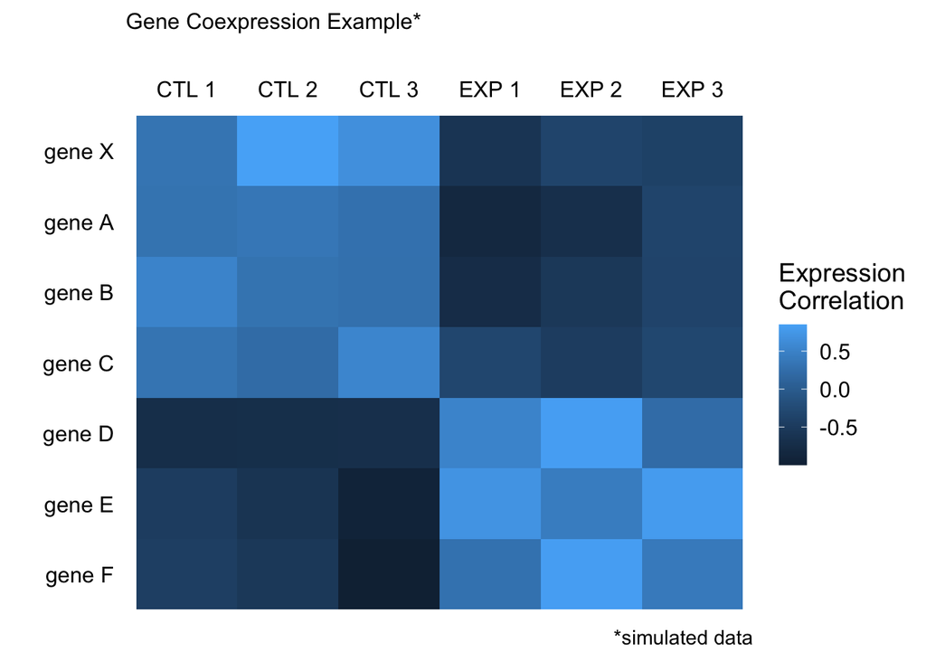

Following on this idea, we set out to map genes to common functional pathways based on dependence of a pathway for cell viability. Project Achilles is a systematic effort by the [Broad Institute](https://www.broadinstitute.org) as part of a larger [‘DepMap’ project](http://www.depmap.org) aimed at identifying and cataloging gene essentiality across hundreds of well-characterized cancer cell lines using highly standardized pooled genome-scale loss-of-function screens. This project uses lentiviral-based pooled RNAi or CRISPR/Cas9 libraries to systematically knock-out each gene in the genome, which allows for the stable suppression/ablation of each gene individually in a subset of cells within a pooled format allowing for genome wide interrogation of gene essentiality. Using computational modeling, a normalized value of gene essentiality is given for each gene in a single cell line. A lower score means that a gene is more likely to be essential in a given cell line. A score of -1 corresponds to the median of all common essential genes, whereas a score of 0 is equivalent to a gene that is not essential; a positive score indicates a gain in fitness and often identifies tumor suppressor genes.

It is well-known that human cancer cell lines rely on different pathways for their viability. Indeed this is the entire rationale for personalized, precision medicine in cancer. The overall goal of the ‘DepMap’ project is to identify all essential genes in 2000 cell lines over the 5-year project period to identify new therapeutic targets in various cancers. Despite not knowing the mechanistic basis for why some cell lines require specific genes while other cell lines do not, we reasoned that intrinsic reliance of a cell on a pathway might allow unbiased detection of novel genes participating in specific pathways.

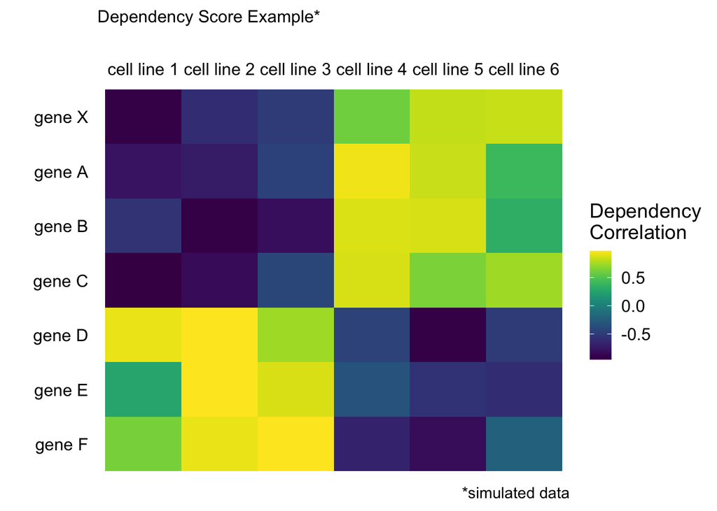

## What did I do?

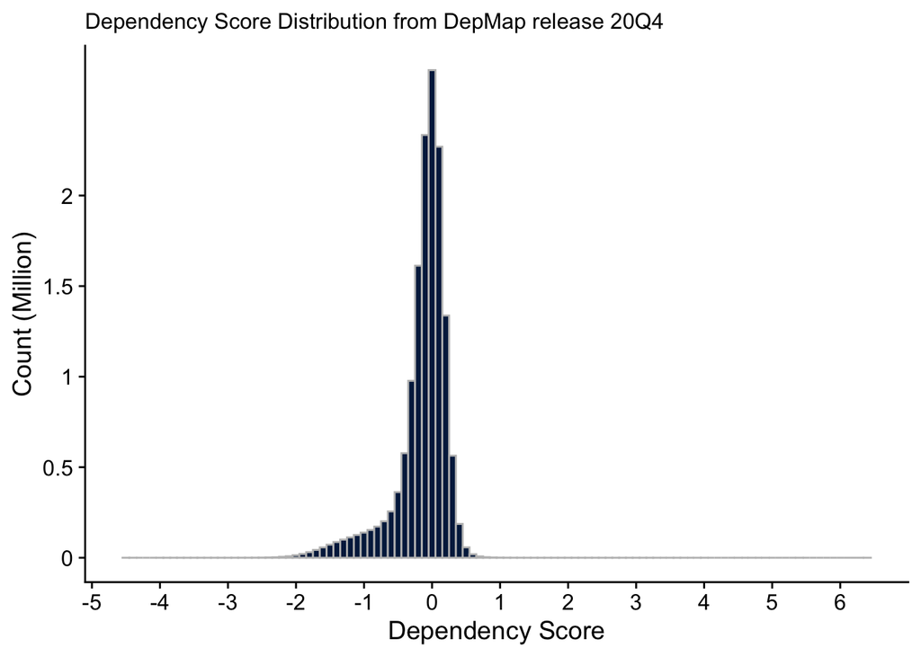

#### Predictive analytics by pattern recognition

To find patterns in gene dependencies across cell lines, we generated a Pearson correlation matrix of all genes by all genes. This analysis generated gene-gene correlation values that matched values published on depmap.org, validating the first step in our analysis. High levels of gene expression are often thought to be indicative of key genes for a given cell type. Thus, we next compared dependency values to gene expression values. The [Cancer Cell Line Encyclopedia](https://portals.broadinstitute.org/ccle/about) project is a collaboration between the Broad Institute, and the Novartis Institutes for Biomedical Research and its Genomics Institute of the Novartis Research Foundation, which together conduct detailed genetic and pharmacologic characterization of a large panel of human cancer models. As of the CCLE 2019 release, 1376 cell lines have been characterized for gene expression. In the 20Q4 DepMap release, 800 of the 808 cell lines have gene expression data. Using these two datasets, we compared the essentiality of a gene to its expression value.

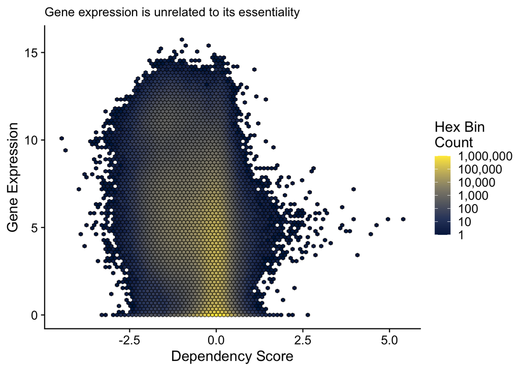

#### Noise Reduction

Given cells do not express all genes, but might receive a dependency score in this experimental paradigm, we sought to remove dependency scores for gene-cell line pairs that have an expression value of zero under basal conditions. Of the 808 cell lines for which gene essentiality data is collected, 800 have genome-wide gene expression data. From these cell lines, we removed dependency scores for genes from cell line that have a corresponding gene expression value of zero.

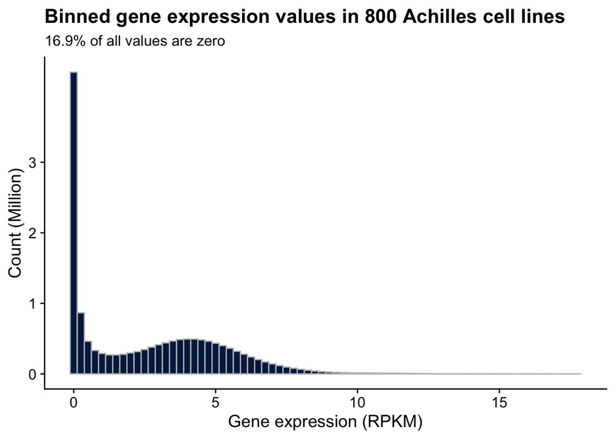

For some genes expressed in highly specific and restricted cell types, this operation removed many dependency values. After removing these values, we found that highly specialized genes in discrete cell types have too few cells with both gene expression values and gene essentiality values to assign a meaningful correlation value. Thus, if a gene was absent from too many cell lines, we omitted it to prevent assigned values from relying on too few data points.

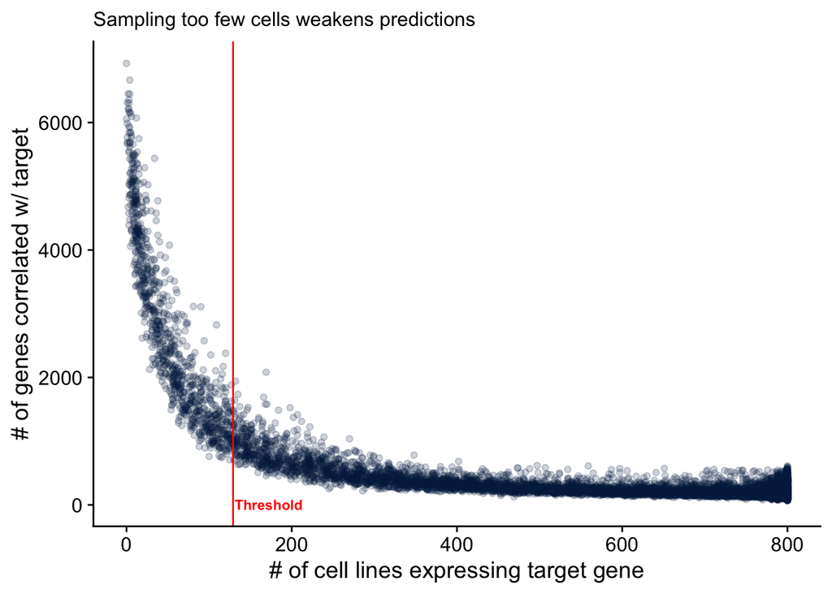

We set a threshold of no more than 679 zeros, meaning that if a gene had fewer than 129 cell lines with dependency values, the correlation pattern of a gene would be meaningless, and that gene was therefore removed. This value was based on removing 5 % of the genes with the fewest number of cells deriving the correlation value and having the highest number of correlated gene patterns. This process removed 907 genes that had too few cells with expression and dependency data.

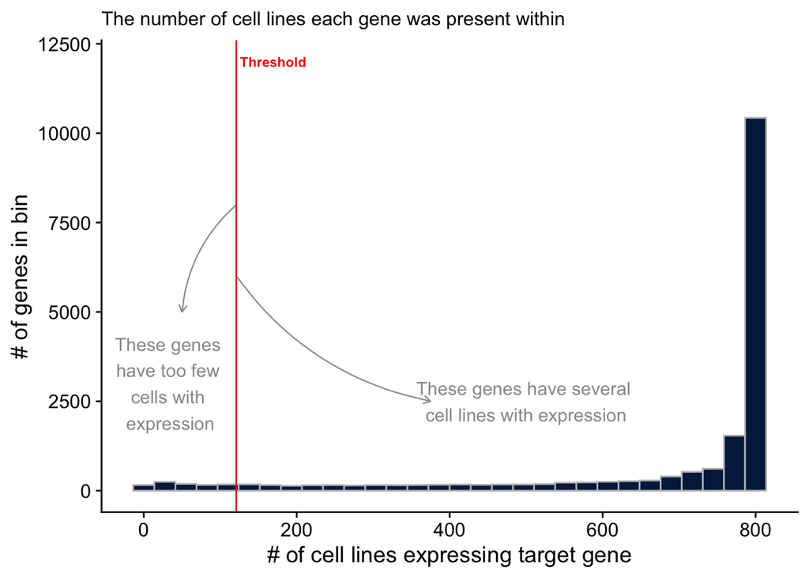

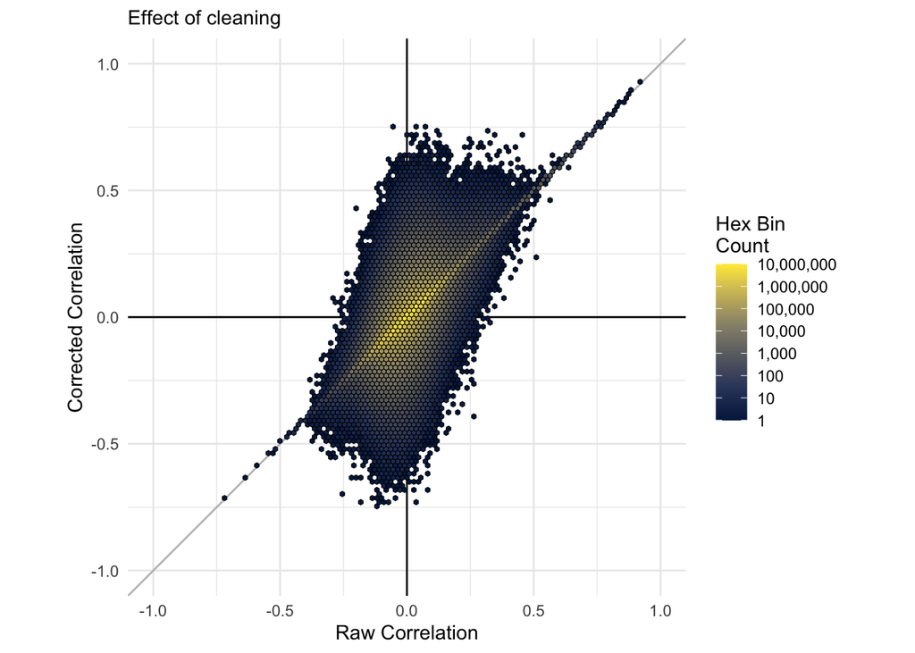

## How does it work?

To identify genes that shared similar patterns of essentiality with other genes, thereby placing genes in functional pathways, we generated a gene-by-gene Pearson correlation matrix on these prioritized data to quantify the similarity in dependency patterns and annotate genes in functional pathways.

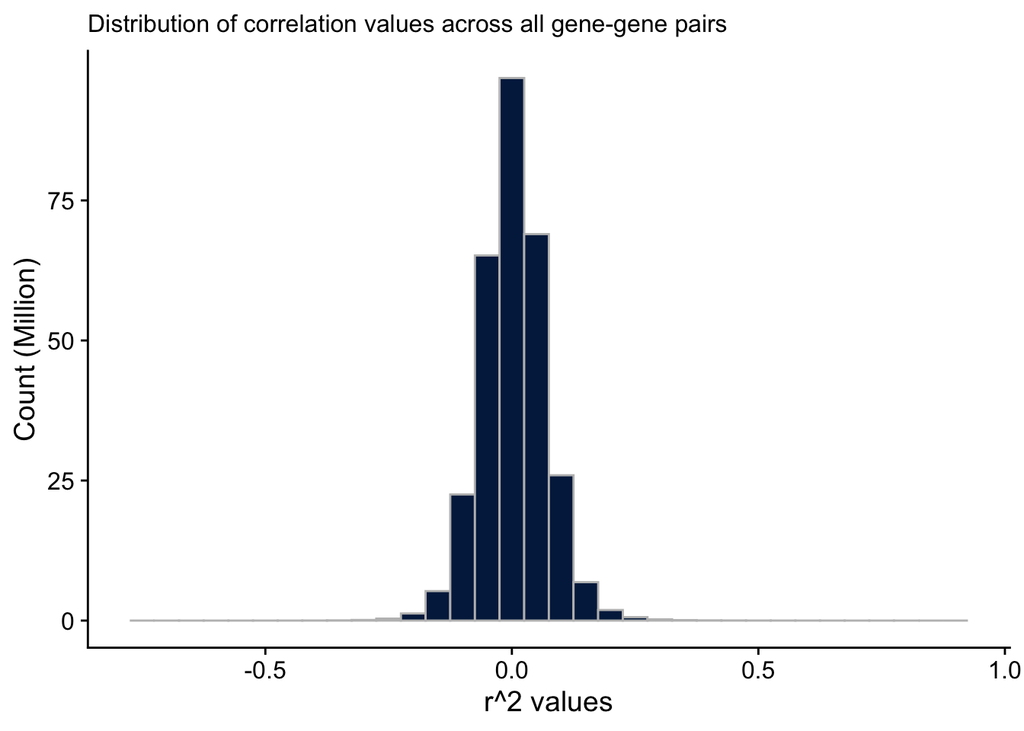

This process generated approximately 296 million correlation values, with a distribution centered around zero. This output produced a range of maximum correlation values for each gene.

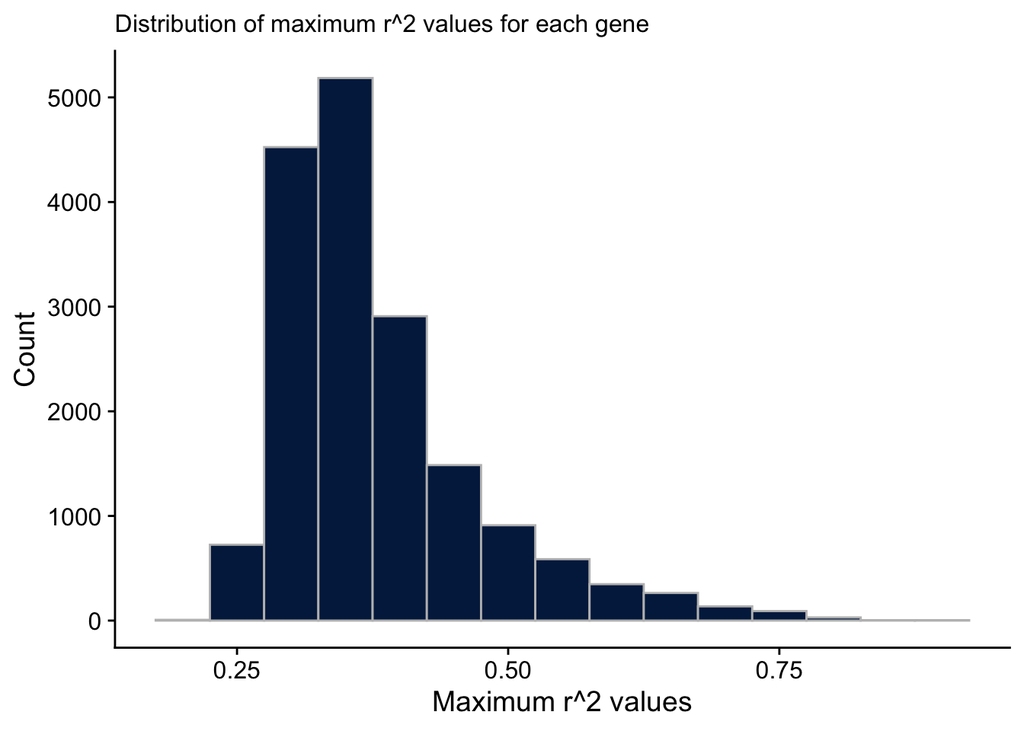

#### Statistics

Rather than setting an arbitrary threshold for the r^2 value that would be considered a low, medium, or high correlation between two genes, we performed a permutation test on the correlated data. A permutation test involves permuting one or more variables in a data set before performing the test, in order to break any existing relationships and simulate the null hypothesis. In this case, we broke the relationship between gene-gene pairs and the correlation values. We then generated a distribution of null statistics (fake means), along with standard deviations of these sampled data. This strategy identified at which correlation value to draw a threshold of a “significant correlation” for these analyses. We sampled 20,000 r^2 values from all gene-gene pairs without replacement simulating a virtual Achilles correlation dataset for a single cell. We then repeated this process 1000 times mimicking 1000 discrete cell lines.

This statistical analysis produced the following data:  
**Mean:** 0.0035082  
**Standard Deviation:** 0.0656911

Using a standard deviation threshold of 3, we calculated the boundaries of r^2 values to be greater than 0.2 or lower than -0.19 for negative correlations. Simply stated, gene-gene correlations above or below, respectively, these values were considered strong and used for subsequent analyses. The r^2 values and corresponding z-score transformations of these values are shown on the tables.

#### Comparing to Known Literature

The process of generating a prioritized gene list based on similar patterns to a query gene is an unbiased approach to map genes into functional pathways. To find novel genes in established pathways, this approach requires identifying “novel” or “unexpected” genes in the gene list. However, what may seem unexpected to one researcher might be obvious or intuitive to another. To remove bias in prioritizing candidate genes for further study and to programatically identify novelty, we generated a **co-publication index**, where every human gene was compared to publication co-incidence with every other human gene in the [PubMed](https://pubmed.ncbi.nlm.nih.gov) database.

PubMed contains 30 million publication records containing article metadata and abstracts. We began by first parsing each of the 30 million abstracts for all gene names and gene aliases in an abstract. Next we were able to generate article level summaries for each gene in each article, and then counted gene-gene co-occurrence in an abstract. Measuring all human gene-gene co-occurrences across all PubMed records allowed us to identify the frequency with which a gene was published with another gene. Unfortunately, gene nomenclature is a mess, with official gene names changing over time, and several genes sharing common aliases. As a keystone example, the protein p38 has been used as a name to describe the genes MAPK14 (NCBI gene id 1432), AHSA1 (NCBI gene id 10598), and AIMP2 (NCBI gene id 7965). The protein p38 associated with MAPK14 is among the most studied and published on genes in the human genome, whereas AHSA1 and AIMP2 are among the least studied. This discrepancy and ambiguity in identifying genes in abstracts necessitated an alternative approach.

Next, we leveraged a PubMed resource from the National Library of Medicine (NLM) called gene2pubmed that links unique NCBI gene ids to a PubMed id. This resource is part of the NLM’s Indexing Initiative (IND) is working to automate indexing methods partially or completely manual indexing practices. Using gene2pubmed, we again measured all human gene-gene co-occurrences across all PubMed records. While this method overcomes the challenges associated with gene nomenclature by providing gene ids, it is still limited in its ability to curate genes associated with scientific papers by the same challenges in gene nomenclature.

A new machine learning (ML)-based resource developed by the Computational Biology Branch at the NLM/NCBI called [Pubtator](https://www.ncbi.nlm.nih.gov/research/pubtator/) aims to overcome these challenges by providing automatic annotations of biomedical concepts such as genes and mutations in PubMed abstracts and PMC full-text articles. Using advanced text-mining techniques, Pubtator goes beyond assigning genes to paper by developing a ML model that generates automated annotations for genes/proteins, genetic variants, diseases, chemicals, species and cell lines in a single paper, across all PubMed (30 million) abstracts and the PMC Text Mining subset of (3 million full text) articles.Improved concept identification systems and a new disambiguation module based on deep learning provides best-in-class annotation accuracy. Using these data, we filtered “concept ids” that matched official NCBI gene IDs, and then took the same approach described above to determine the number of times a gene was annotated with scientific paper, and the pairwise count of each gene with each other gene in a single paper, across all papers. Because of the wide range of annotated gene co-occurrences (0 to 26750), we also generated a relative index [(co-occurrence count/max co-occurrence)*100] normalized to 100. The co-occurrence count and co-occurrence index provides useful, and unbiased information about the level of prior knowledge for gene-gene relationship identified by the analytic approach detailed above.

#### Pathway Analyses

To identify clusters of genes with shared relationships, we performed gene set enrichment analysis. Enrichment analysis is a computational method for inferring knowledge about a target gene set by comparing it to annotated gene sets representing prior biological knowledge. Enrichment analysis determines whether an input set of genes significantly overlaps with annotated gene sets. For each gene in our matrix, we determined the number of genes that were greater than or less than 3 standard deviations away from the permuted mean. This target gene list was then queried against 108 gene sets across a [broad range of curated data](https://amp.pharm.mssm.edu/Enrichr/#stats). By leveraging the [Enrichr](https://amp.pharm.mssm.edu/Enrichr/) resource from the [Ma’ayan Laboratory](http://labs.icahn.mssm.edu/maayanlab/), we determined the top ranked pathways, processes, drugs, cell lines, tissues, or diseases, and ranked by p-value. In this setting, the p-value is computed using a standard statistical method used by most enrichment analysis tools: Fisher’s exact test or the hypergeometric test. This is a binomial proportion test that assumes a binomial distribution and independence for probability of any gene belonging to any set. [See here for more information about how Enrichr computes its associations](https://amp.pharm.mssm.edu/Enrichr/help#background).

#### Network Analyses

As an alternative approach to prioritize further study of novel functional mappings, an interactive network graph of gene-gene relationships can be built. A single gene query results in a list of top and bottom associated genes based on patterns of gene dependency scores. The top 10 and bottom 10 genes are then queried for each of their top and bottom correlated genes. These resulting 400 gene pairs (20 genes * 20 genes) are then used to build a network graph, which can reveal if a top associated gene with the query gene, also has the query gene in its top (or bottom) 10. In this way, strong functional networks can be identified and prioritized for further study.

## How do I use this?

In order to identify the functional annotation of a single gene, begin with a query. Entering a single gene in the search box produces a series of tables and plots that identifies a functional map of the processes that gene *might* be involved in. In some cases, querying a gene with known functions will identify genes with well-established connections to the query gene; in other cases, new genes and new biological process might be identified, suggesting there is more to discover for well-known pathways. Querying unknown genes is especially powerful, as the associated genes and pathways provide a starting point for an otherwise difficult problem to prioritize experimentally.

#### 1. Query YFG (your favorite gene)

As an example, we will query the protein P53. Typing in the given protein name “P53” produces an error, because the official gene symbol needs to be entered. Querying TP53 (official gene symbol) generates a short summary of the gene, its name and list of aliases, and an Entrez gene summary paragraph when available.

#### Summary

**Gene**: TP53  
**Name**: Tumor protein p53  
**aka**: p53, LFS1  
**Entrez ID**: 7157

This gene encodes a tumor suppressor protein containing transcriptional activation, DNA binding, and oligomerization domains. The encoded protein responds to diverse cellular stresses to regulate expression of target genes, thereby inducing cell cycle arrest, apoptosis, senescence, DNA repair, or changes in metabolism. Mutations in this gene are associated with a variety of human cancers, including hereditary cancers such as Li-Fraumeni syndrome. Alternative splicing of this gene and the use of alternate promoters result in multiple transcript variants and isoforms. Additional isoforms have also been shown to result from the use of alternate translation initiation codons from identical transcript variants (PMIDs: 12032546, 20937277). [provided by RefSeq, Dec 2016]

#### 2. Dependencies

The first plot shows the distribution of dependency scores across 808 cell lines ranked from lowest (strongest dependencies) to highest (no dependency or inverse). Each of the 808 cell lines is represented by a single point on the plot. Generally, values below -1 indicate the gene of interest (TP53 in this example) is essential in that cell line; values between -1 and 0, mean that cells lose fitness, but the gene is not essential; values hovering around zero indicate that ablation of TP53 has little effect on cell growth; values above 1, indicate that knocking-out the gene leads to a fitness advantage. In the case of TP53, several cells have a fitness advantage in its absence, consistent with its role as a tumor suppressor.

The second plot is a histogram of dependency scores, showing the distribution of scores for TP53. While the majority of cells have little change in cellular growth when TP53 is absent (the histogram is centered around zero), some cells require TP53 for growth (cells scoring below -1), whereas in other cells TP53 functions as a tumor suppressor (cells with a score above 1).

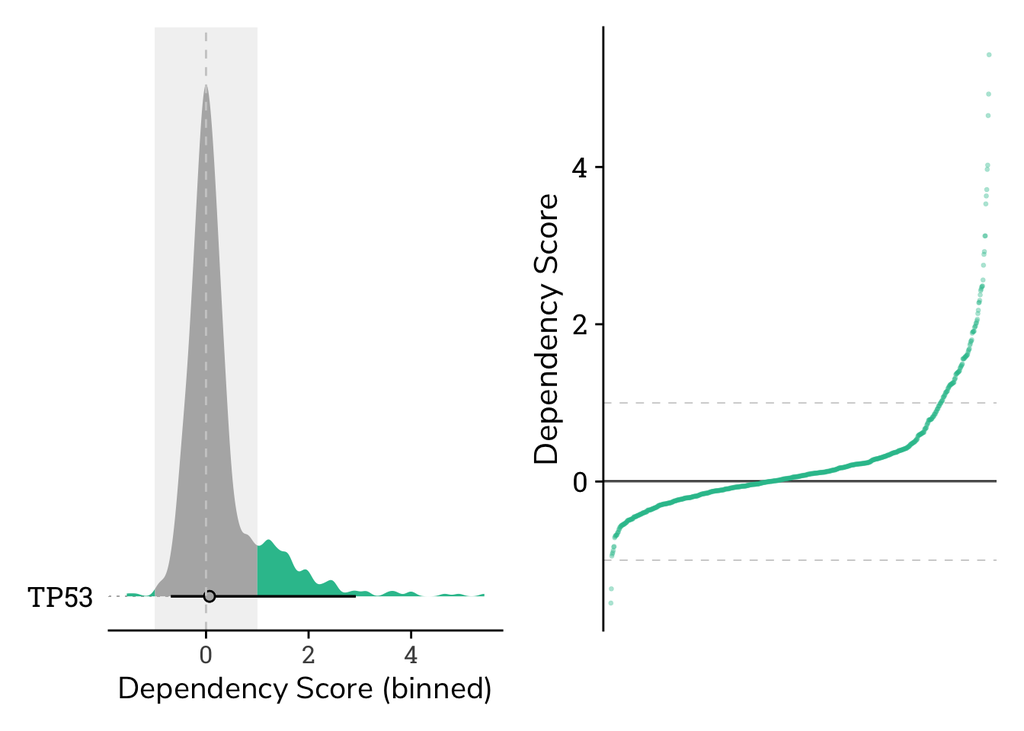

To identify the cells at the tails of the plots, a dependency table will show the ranked cells by dependency score, with cell lineage information appended. In some cases, specific cell types or lineages will show consistent patterns of dependency on a gene.

#### Cells with strong TP53 genetic dependencies:

[output not shown]

#### Cells with low or inverse TP53 genetic dependencies

[output not shown]

Understanding the shape of the curve and distribution of the raw data underlying the patterns is important for interpreting the results.

#### 3. Similar Patterns

Positive correlations of dependency scores are ranked for each gene. Recall that these genes show similar patterns of dependencies in the same cell lines. More simply, the cells that care about TP53 deletion also care about deletion of these genes, implying a functional relationship. In the Dependency Score Example heatmap schematic above, TP53 is gene X, and genes with similar patterns would be genes A, B, and C. The 190 genes that show a similar genetic dependencies as TP53 and are above 3 standard deviations away from the resampled mean are displayed.

| Query | Gene | Name | Z Score | R^2 | Co-publication Count | Co-publication Index |
| --- | --- | --- | --- | --- | --- | --- |
| TP53 | TP53BP1 | Tumor protein p53 binding protein 1 | 11.2 | 0.74 | 3113 | 16 |
| TP53 | CDKN1A | Cyclin dependent kinase inhibitor 1a | 10.9 | 0.72 | 16379 | 82 |
| TP53 | USP28 | Ubiquitin specific peptidase 28 | 10.1 | 0.67 | 283 | 1 |
| TP53 | CHEK2 | Checkpoint kinase 2 | 10.1 | 0.67 | 6109 | 31 |
| TP53 | ATM | Atm serine/threonine kinase | 9.1 | 0.60 | 12593 | 63 |
| TP53 | XPO7 | Exportin 7 | 6.3 | 0.42 | 48 | 0 |
| TP53 | UBE2K | Ubiquitin conjugating enzyme e2 k | 6.3 | 0.42 | 196 | 1 |
| TP53 | RPL22 | Ribosomal protein l22 | 6.2 | 0.41 | 275 | 1 |
| TP53 | FAM193A | Family with sequence similarity 193 member a | 5.9 | 0.39 | 4 | 0 |
| TP53 | ZNF326 | Zinc finger protein 326 | 5.6 | 0.37 | 25 | 0 |

These 190 genes were queried for gene set enrichment, and the gene sets and pathways with the strongest statistical significance are shown. Simply stated, these are the pathways that best represent the list of genes that share similar genetic dependencies, and suggest that the query gene is part of these pathways.

| Query | Gene Set | Gene List | Overlap | Adjusted p-value | Combined Score | Genes |
| --- | --- | --- | --- | --- | --- | --- |
| TP53 | GO Biological Process 2018 | mitochondrial translation (GO:0032543) | 28/107 | 0 | 2023.782 | MRPS16;MRPS14;MRPS11;MRPL38;MRPL17;MRPS10;MRPL12;MRPL34;MRPL57;MRPL33;MRPL2;MRPL40;RARS2;MRPS28;PTCD3;GADD45GIP1;MRPS26;MRPS27;MRPS24;MRPS25;MRPL47;MRPL23;MRPS7;QRSL1;HARS2;MRPS6;MRPL21;LARS2 |
| TP53 | GO Biological Process 2018 | mitochondrial translational elongation (GO:0070125) | 24/87 | 0 | 1870.113 | MRPS28;PTCD3;GADD45GIP1;MRPS26;MRPS16;MRPS27;MRPS24;MRPS14;MRPS25;MRPS11;MRPL38;MRPS10;MRPL17;MRPL47;MRPL34;MRPS7;MRPL12;MRPL23;MRPS6;MRPL57;MRPL21;MRPL33;MRPL2;MRPL40 |
| TP53 | GO Biological Process 2018 | mitochondrial translational termination (GO:0070126) | 24/89 | 0 | 1810.677 | MRPS28;PTCD3;GADD45GIP1;MRPS26;MRPS16;MRPS27;MRPS24;MRPS14;MRPS25;MRPS11;MRPL38;MRPS10;MRPL17;MRPL47;MRPL34;MRPS7;MRPL12;MRPL23;MRPS6;MRPL57;MRPL21;MRPL33;MRPL2;MRPL40 |
| TP53 | Reactome 2016 | Mitochondrial translation elongation Homo sapiens R-HSA-5389840 | 23/84 | 0 | 1773.681 | MRPS28;PTCD3;GADD45GIP1;MRPS26;MRPS16;MRPS27;MRPS24;MRPS14;MRPS25;MRPS11;MRPL38;MRPS10;MRPL17;MRPL47;MRPL34;MRPS7;MRPL12;MRPL23;MRPS6;MRPL21;MRPL33;MRPL2;MRPL40 |
| TP53 | Reactome 2016 | Mitochondrial translation termination Homo sapiens R-HSA-5419276 | 23/84 | 0 | 1773.681 | MRPS28;PTCD3;GADD45GIP1;MRPS26;MRPS16;MRPS27;MRPS24;MRPS14;MRPS25;MRPS11;MRPL38;MRPS10;MRPL17;MRPL47;MRPL34;MRPS7;MRPL12;MRPL23;MRPS6;MRPL21;MRPL33;MRPL2;MRPL40 |
| TP53 | GO Biological Process 2018 | translational termination (GO:0006415) | 24/96 | 0 | 1625.393 | MRPS28;PTCD3;GADD45GIP1;MRPS26;MRPS16;MRPS27;MRPS24;MRPS14;MRPS25;MRPS11;MRPL38;MRPS10;MRPL17;MRPL47;MRPL34;MRPS7;MRPL12;MRPL23;MRPS6;MRPL57;MRPL21;MRPL33;MRPL2;MRPL40 |
| TP53 | Reactome 2016 | Mitochondrial translation initiation Homo sapiens R-HSA-5368286 | 23/84 | 0 | 1773.681 | MRPS28;PTCD3;GADD45GIP1;MRPS26;MRPS16;MRPS27;MRPS24;MRPS14;MRPS25;MRPS11;MRPL38;MRPS10;MRPL17;MRPL47;MRPL34;MRPS7;MRPL12;MRPL23;MRPS6;MRPL21;MRPL33;MRPL2;MRPL40 |
| TP53 | Reactome 2016 | Mitochondrial translation Homo sapiens R-HSA-5368287 | 23/90 | 0 | 1607.743 | MRPS28;PTCD3;GADD45GIP1;MRPS26;MRPS16;MRPS27;MRPS24;MRPS14;MRPS25;MRPS11;MRPL38;MRPS10;MRPL17;MRPL47;MRPL34;MRPS7;MRPL12;MRPL23;MRPS6;MRPL21;MRPL33;MRPL2;MRPL40 |
| TP53 | GO Biological Process 2018 | translational elongation (GO:0006414) | 24/105 | 0 | 1429.317 | MRPS28;PTCD3;GADD45GIP1;MRPS26;MRPS16;MRPS27;MRPS24;MRPS14;MRPS25;MRPS11;MRPL38;MRPL17;MRPS10;MRPL47;MRPL12;MRPL23;MRPL34;MRPS7;MRPS6;MRPL57;MRPL21;MRPL33;MRPL2;MRPL40 |
| TP53 | CORUM | 55S ribosome, mitochondrial (human) | 21/78 | 0 | 1582.320 | MRPS28;MRPS26;MRPS16;MRPS27;MRPS24;MRPS14;MRPS25;MRPS11;MRPL38;MRPS10;MRPL17;MRPL47;MRPL34;MRPS7;MRPL12;MRPL23;MRPS6;MRPL21;MRPL33;MRPL2;MRPL40 |

#### 4. Dissimilar

Like the analysis for genes that share similar patterns, this analysis can be used to find genes that share distinctly dissimilar patterns; that is, genes that have an inverse correlation of dependences. Simply stated, the cells that care about TP53 deletion *do not* care about deletion of these genes, implying an inverse or opposing relationship. In the Dependency Score Example heatmap schematic above, TP53 is gene X, and genes with dissimilar patterns would be genes D, E, and F. The 243 genes that show inverse genetic dependencies to TP53 and are below 3 standard deviations away from the resampled mean are:

| Query | Gene | Name | Z Score | R^2 | Co-publication Count | Co-publication Index |
| --- | --- | --- | --- | --- | --- | --- |
| TP53 | MDM2 | Mdm2 proto-oncogene | -10.9 | -0.71 | 17403 | 100 |
| TP53 | PPM1D | Protein phosphatase, mg2+/mn2+ dependent 1d | -9.0 | -0.59 | 958 | 6 |
| TP53 | MDM4 | Mdm4 regulator of p53 | -7.5 | -0.49 | 2561 | 15 |
| TP53 | PPM1G | Protein phosphatase, mg2+/mn2+ dependent 1g | -7.1 | -0.46 | 112 | 1 |
| TP53 | WDR89 | Wd repeat domain 89 | -6.9 | -0.45 | 5 | 0 |
| TP53 | DDX31 | Dead-box helicase 31 | -6.8 | -0.44 | 29 | 0 |
| TP53 | USP7 | Ubiquitin specific peptidase 7 | -6.8 | -0.44 | 1047 | 6 |
| TP53 | FERMT2 | Fermitin family member 2 | -6.1 | -0.40 | 128 | 1 |
| TP53 | TERF1 | Telomeric repeat binding factor 1 | -5.8 | -0.38 | 826 | 5 |
| TP53 | NSUN5 | Nop2/sun rna methyltransferase 5 | -5.4 | -0.35 | 36 | 0 |

These 243 genes were also queried for gene set enrichment, and the gene sets and pathways with the strongest statistical significance are shown. Simply stated, these are the pathways that best represent the list of genes that have inverse genetic dependencies.

| Query | Gene Set | Gene List | Overlap | Adjusted p-value | Combined Score | Genes |
| --- | --- | --- | --- | --- | --- | --- |
| TP53 | TF Perturbations Followed by Expression | ZEB2 SHRNA H1 HUMAN GSE69618 DAY2 RNASEQ UP | 44/580 | 0 | 315.26879 | TOP2B;RPL30;CCNT2;RPL32;BOD1L1;MSI2;RPL9;RPL6;RPL7;TAF1D;RPL18A;RPL36AL;RPS3;RPL14;PAPOLA;RPL35;ITGAV;SEPHS1;RPS11;RPS27A;RPL19;PDIA3;RPL23;NONO;ZFR;ATRX;PRRC2C;PRPF4B;RPL23A;ENAH;AFDN;CENPF;DPPA4;NAC… |
| TP53 | RNA-Seq Disease Gene and Drug Signatures from GEO | PRMT9 HeLa knockdown GSE63953 down | 41/498 | 0 | 339.09026 | TOP2B;RPL30;RPL32;HEATR1;BOD1L1;NOLC1;DDX21;RPL9;RPL6;RPL7;WDR44;PPM1G;RPL18A;PCF11;EXO1;BTBD3;RPS3;USP1;RPL14;SACS;KNTC1;ITGAV;RPS11;RPS27A;RPL19;PARP1;CBX3;RPL23;NONO;CEP295;ATRX;RPL23A;ENAH;CENPF;N… |
| TP53 | Jensen TISSUES | Cervical carcinoma cell | 128/4876 | 0 | 103.69533 | RPL30;ERCC6L;TRIO;CCNT2;ZWILCH;ZFAND6;BCCIP;EHMT1;MSI2;TTF1;RPL6;RPL7;IPO9;RPL18A;PPP4R2;RPL36AL;SACS;PAPOLA;CIR1;KNTC1;SEPHS1;SOX5;SRRM2;FNBP4;USP7;RPL23;DNTTIP2;WDR75;MITF;PRPF4B;ARMC5;PSME3;ZW10;NC… |
| TP53 | GTEx Tissue Sample Gene Expression Profiles up | GTEX-S95S-0002-SM-3NM8K blood male 60-69 years | 110/3958 | 0 | 99.30881 | DCLRE1B;RPL30;ERCC6L;RPL32;ZWILCH;CEP120;BCCIP;EHMT1;PPP2R2A;WDR89;TTF1;RPL9;RPL6;RPL7;IPO9;RPL18A;PPP4R2;RPL36AL;SACS;PAPOLA;RPL35;KNTC1;RPS11;PDIA3;USP7;RPL23;WDR75;GPATCH11;ZNF92;PSME3;NCL;MRTO4;SR… |
| TP53 | GTEx Tissue Sample Gene Expression Profiles up | GTEX-SIU7-0001-SM-3NMAW blood male 50-59 years | 106/3711 | 0 | 102.16993 | DCLRE1B;RPL30;ERCC6L;RPL32;ZWILCH;BCCIP;EHMT1;PPP2R2A;WDR89;TTF1;RPL6;RPL7;RPL18A;PPP4R2;RPL36AL;C19ORF53;PAPOLA;RPL35;KNTC1;RPS11;PDIA3;USP7;RPL23;DNTTIP2;WDR75;GPATCH11;ZNF92;PSME3;NCL;MRTO4;SRFBP1;… |
| TP53 | GTEx Tissue Sample Gene Expression Profiles up | GTEX-T6MN-0002-SM-3NMAH blood male 50-59 years | 110/4038 | 0 | 93.81101 | DCLRE1B;RPL30;ERCC6L;RPL32;ZWILCH;BCCIP;EHMT1;PPP2R2A;WDR89;TTF1;RPL9;RPL6;RPL7;IPO9;RPL18A;PPP4R2;RPL36AL;C19ORF53;SACS;PAPOLA;RPL35;KNTC1;SEPHS1;RPS11;USP7;RPL23;DNTTIP2;WDR75;LIG4;PRPF4B;GPATCH11;Z… |
| TP53 | RNA-Seq Disease Gene and Drug Signatures from GEO | Myc RKO knockdown GSE68219 down | 37/497 | 0 | 255.62642 | RPL30;RPL32;HEATR1;BCCIP;NOLC1;DDX21;RPL9;RPL6;WDR43;IPO4;RPL7;PPM1G;RPL18A;RPS3;RPL14;SACS;PAPOLA;RPL35;RPS27A;RPL19;SRRM2;SPEN;USP7;PARP1;CBX3;DNTTIP2;PRRC2C;CENPF;NACA;PSME3;RPL27A;NCL;MRTO4;MDM2;R… |
| TP53 | GTEx Tissue Sample Gene Expression Profiles up | GTEX-XLM4-0004-SM-4AT5I blood male 60-69 years | 110/4053 | 0 | 92.81628 | DCLRE1B;RPL30;ERCC6L;RPL32;ZWILCH;ZFAND6;BCCIP;EHMT1;WDR89;TTF1;RPL9;RPL6;RPL7;IPO9;RPL18A;PPP4R2;RPL36AL;C19ORF53;SACS;PAPOLA;RPL35;KNTC1;SEPHS1;RPS11;USP7;RPL23;DNTTIP2;WDR75;LIG4;PRPF4B;GPATCH11;ZN… |
| TP53 | GTEx Tissue Sample Gene Expression Profiles up | GTEX-UPJH-0001-SM-3NMDE blood male 50-59 years | 107/3891 | 0 | 92.95933 | DCLRE1B;RPL30;ERCC6L;RPL32;ZWILCH;BCCIP;EHMT1;PPP2R2A;WDR89;TTF1;RPL6;RPL7;RPL18A;PPP4R2;RPL36AL;C19ORF53;SACS;PAPOLA;RPL35;KNTC1;RPS11;PDIA3;USP7;RPL23;DNTTIP2;WDR75;GPATCH11;ZNF92;PSME3;NCL;AKIP1;MR… |
| TP53 | GTEx Tissue Sample Gene Expression Profiles up | GTEX-U3ZN-0002-SM-3NMDF blood female 30-39 years | 110/4071 | 0 | 91.63714 | DCLRE1B;RPL30;ERCC6L;TRIO;RPL32;ZWILCH;CEP120;BCCIP;EHMT1;PPP2R2A;MSI2;WDR89;TTF1;RPL9;RPL6;RPL7;RPL18A;PPP4R2;RPL36AL;C19ORF53;PAPOLA;RPL35;CIR1;KNTC1;RPS11;FNBP4;USP7;RPL23;DNTTIP2;WDR75;GPATCH11;ZN… |

How to interpret these genes and pathways is more variable than the positively correlated genes and pathways. In some cases, a negative regulator of a gene has a negative correlation with that gene, such as in this example with TP53 and its negative regulator MDM2. In other cases, opposing *pathways* are shown, contrasting the TP53 enriched pathway term “GO Biological Process 2018” with the dissimilar enriched pathway term “GTEx Tissue Sample Gene Expression Profiles up”, revealing two opposing biological pathways.

#### 5. Graph

Identifying genes that share similar patterns of dependency to a queried unknown gene generates strong hypotheses about new functional annotations and maps to new pathways. However, the strength of the hypothesis cannot be fully inferred from single gene list. If a new gene is associated with the queried gene, then you might infer a functional relationship. However, if you inspect the top 10 genes with the queried gene, then inspect the top 10 genes of each of those, building a functional network graph of the top related genes might reveal a stronger association of the new gene with your queried gene *and* its top ranked genes.

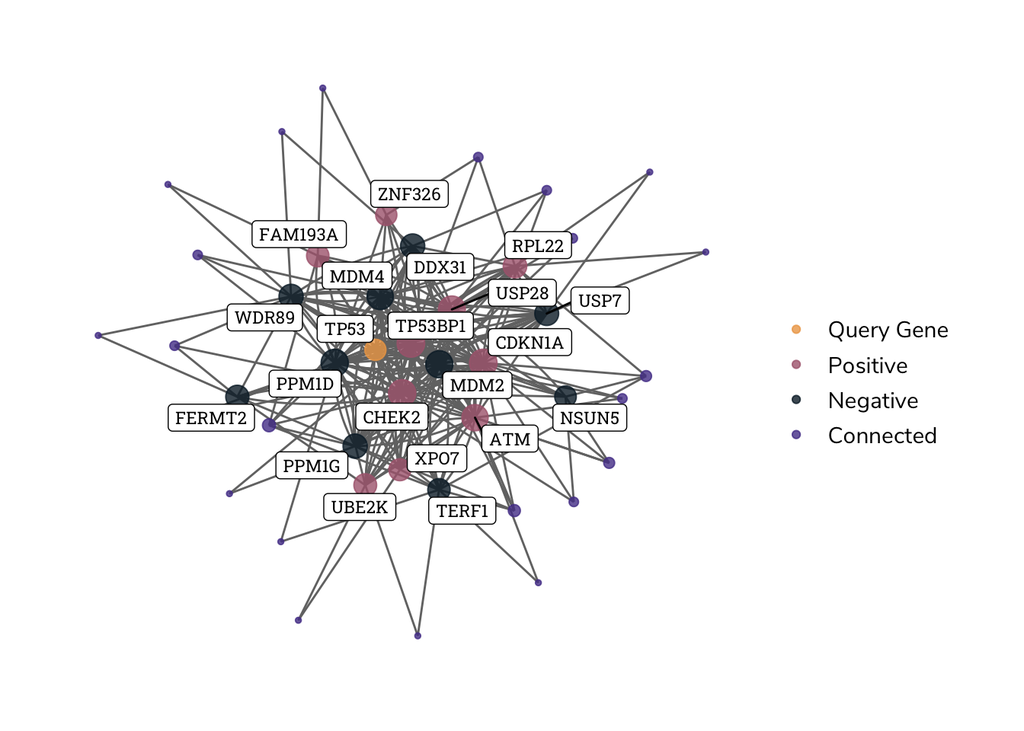

The image here is a representative static, albeit busy, network graph; data presented on datadrivenhypothesis.org is an interactive image that can be zoomed, dragged, and manipulated for data exploration.

## Broader Implications

Like the proverbial man [searching for his lost keys under the lamp post](https://www.matthewhirschey.com/articles/exploratory-mind) because the light shines there, searching for biological truths often occurs under ‘lamp posts’ because that’s where scientists can see. But what if your keys are not under the light? Or your gene is totally unknown? What do you do?

The scientific method has guided scientific minds for hundreds of years, starting with a question, followed by a hypothesis, and then an experimental path to test the prediction. While hypotheses are the bedrock of science, the volume, complexity, and sophistication of modern science necessitate new methods to generate hypotheses.

New tools in Data Science – a combination of computer programming, math & statistics, and topical expertise – combined with the rapid adoption of open science and data sharing allow scientists to access publicly available datasets and interrogate these data *before* performing any experiments.

Imagine having strong data to support your new hypothesis *before* testing it. This is data-driven hypothesis.

## Where do I get more information?

Code is available on the [Hirschey Lab github account](https://github.com/matthewhirschey/ddh), including links to download the raw data, and run the analyses in R from scratch. Furthermore, the Broad Institute has a lot of information on their [website](http://www.broadinstitute.org) and the website dedicated to the [Dependency Map project](http://www.depmap.org) about how the raw data were generated, and provide a list of references.

#### Code Availability

[Generate Data](https://github.com/matthewhirschey/ddh/blob/master/code/generate_depmap_data.R)  
[Statistical Analyses](https://github.com/matthewhirschey/ddh/blob/master/code/generate_depmap_stats.R)  
[Table Generator](https://github.com/matthewhirschey/ddh/blob/master/code/generate_depmap_tables.R)  
[Pathway Generator](https://github.com/matthewhirschey/ddh/blob/master/code/generate_depmap_pathways.R)

Methods updated January 04, 2021